# Q1. What is our independent variable? What is our dependent variable?

Independant variable is the color of the word. Dependant variable is the time taken to identify the count of colored words.

# Q2. What is an appropriate set of hypothesis for this task? What kind of statistical test do you expect to perform? Justify your choices.

We can do Null and Alternative hypothesis.

Null Hypothesis- There would be a lower mean time for the incongruent tests than the congruent tests or no noticeable difference in time duration between the congruent and incongruent tests This is the result that we want to provide evidence against. This is always an equality and is denoted by H0. In our case for null hypothesis we would assume that, the change in the color of the words doesn't impact the time taken in identifying them. We would prove it wrong.

H0:μ=0

Alternative Hypothesis- There would be a noticeable increase in time duration between the congruent and incongruent tests. This is a result that we are testing against our null hypothesis claim. This value is always an inequality and is denoted by Ha.

Ha:μ≠0

This experiment should be a single-tailed type scenario as we see that the response time always increases in case of incongruent, when compared to congruent response times. It never decreases.

• µc = the mean of time spent for the participant group of congruent test • µi = the mean of time spent for the participant group of incongruent test

The null hypothesis (H0): µc - µi ≥ 0, the time duration difference of the congruent and incongruent tests would be equal to 0 or be greater than 0, meaning the incongruent times would be less or equal to the congruent times for the population.

The alternative hypothesis (HA): µc - µi < 0, the time duration difference of the congruent and incongruent tests would be less than 0, meaning the incongruent times would be greater than the congruent test times for the population.

The recommended statistical test we should use for the Stroop experiment is a T-test as we don’t know the mean of the total population however we have detailed data on a sampled group for both the congruent and incongruent tests. In addition, we only have a data set of 24 people in the sample, making T-test a better choice to do our statistical test.

The type of T-Test selected is: • Dependent: I chose to go the dependent t-test route as even though we do two tests (congruent and incongruent) it is with the same group of people that was tested on the congruent words then tested on the incongruent words. • Paired: I chose to go the paired t-test because the participants were measured at two time points (congruent and incongruent word sets).

# Q3. Report some descriptive statistics regarding this dataset. Include at least one measure of central tendency and at least one measure of variability.

```python
# Import Libraries
import os
DIR = "/Users/poonam/Documents/Poonam/DAND/DAND-Project4"
os.chdir(DIR)
print('Your current working directory: \n', os.getcwd())
print('\nContents in your curent working directory: \n', os.listdir("."))

import numpy as np
import pandas as pd
import matplotlib.pyplot as plt
import seaborn as sns

stroop_df = pd.read_csv('stroopdata.csv')
print (stroop_df.describe())
print (stroop_df.median())
```

```
Your current working directory:
 /Users/poonam/Documents/Poonam/DAND/DAND-Project4

Contents in your curent working directory:
 ['InferentialStatProject-Copy1.ipynb', 'InferentialStatProject.ipynb', 'ipython_notebook_tutorial.ipynb', '.ipynb_checkpoints', 'stroopdata.csv']
       Congruent  Incongruent
count  24.000000    24.000000
mean   14.051125    22.015917
std     3.559358     4.797057
min     8.630000    15.687000
25%    11.895250    18.716750
50%    14.356500    21.017500
75%    16.200750    24.051500
max    22.328000    35.255000
Congruent      14.3565
Incongruent    21.0175
dtype: float64
```

We know our sample size is 24 From the DF description.

Mean of Congruent µc : 14.05 , and median is 14.36 Mean of Incongruent µi: 22.02, and median is 21.02 Mean and median are almost equal so we can assume this distribution to be approximately symmetrical.

Standard deviation of Congruent: 3.56 Standard deviation of Incongruent: 4.80

# Q4. Provide one or two visualizations that show the distribution of the sample data. Write one or two sentences noting what you observe about the plot or plots.

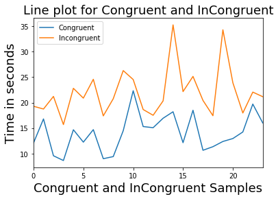

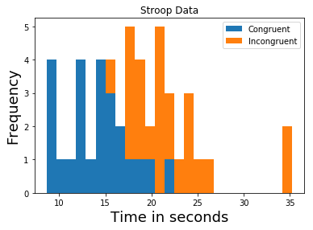

```python
#Line plot
stroop_df.plot()
plt.title('Line plot for Congruent and InCongruent', fontsize=18)
plt.xlabel('Congruent and InCongruent Samples', fontsize=18)
plt.ylabel('Time in seconds', fontsize=18)

# histogram
stroop_df.plot.hist(title="Stroop Data", stacked="false", bins = 25)
plt.xlabel('Time in seconds', fontsize=18)
plt.ylabel('Frequency', fontsize=18)
plt.show()
```

# Q5. Now, perform the statistical test and report your results. What is your confidence level and your critical statistic value? Do you reject the null hypothesis or fail to reject it? Come to a conclusion in terms of the experiment task. Did the results match up with your expectations?

As determined in question 2 we will calculate our data using the T-Test statistical test for the Stroop Effect experiment. Considering the group took both the congruent and incongruent tests this T-Test will be considered dependent and paired.

Knowing the means of each test congruent and incongruent from above mean of congruent µc = 14.05 mean of incongruent µi = 22.02

We can calculate quickly a point estimate using: µc - µi Point_estimate = µc - µi = 14.05-22.02 = -7.97

A point estimate is handy to know as it gives us our “best guess” on the difference of the population between the two tests.

Mean of differences dbar = sigma of difference of congruent values and incongruent values divided by n = 7.96

We can see that point_estimate is almost equal to mean of differences.

## Let's calculate the stantard deviation of the differences value

Using the average of the differences which should match the point estimate of -7.97 we subtract that value from the differences of each person and then square it.

Having this set of squared deviations from the mean we can sum them up into Square of Sums Using ∑sqr(𝒙𝒊 − 𝒙bar) for i = 1 to 24 = 544.33

Given the Square of Sums, lets call it SS, we can use this to determine the variance of the difference. Since we are dealing with a sample we need to use the equation with the denominator of n-1, n being the number of participants on the given tests (n = 24)

variance of difference = (SS)/(n-1) = 544.33/23 = 23.67

Given the Variance for the difference we can use that knowledge to get the standard deviation of differences.

Standard deviation of differences = sqrt(variance of differences) = sqrt(23.67) = 4.87

Given SD of differences, lets call it 's', we can now calculate the T-statistics for the differences.

## T-statistics

T_stat = (mean of congruent - mean of incongruent)/ (s).(sqrt(n))

Given the numerator is the point estimate or average of the differences, and “n” is the number of participants in the Stroop experiment we can calculate the t_stat as:

= -7.97 / (4.87)sqrt(24) = -8.026 T_stat = -8.026

Since we have the T_stat we can compare it to the T_critical value to determine if the null hypothesis should be accepted or rejected.

We know there are 24 participants, which means degree of freedom df = (n-1) = 23

Since we are aiming to find with 99% Confidence level for one tail our α = 0.01. The critical statistic value for a one-tailed test in the negative direction is -2.5

T_critical = -2.5 (from the critical T-Table)

Since the T_stat is in the critical region, the null hypothesis is rejected.

The t-test confirms that incongruent tests would normally take longer than congruent tests. The congruent test linked both visual colors with the correct printed name of the color, while incongruent required to try to separate the visual color and the name of the color which required more response time.

Conclusion:

I reject the null hypothesis, the color of the printed word does cause a greater time response. The results match my expectations.

# Below is some python code used to calculate various values.

```python
stroop_df['diff']  = stroop_df['Incongruent'] - stroop_df['Congruent']
stroop_df['xi-xbar']  = stroop_df['diff'] - (7.964792)
stroop_df['SqrdDiff']  = stroop_df['xi-xbar'] **2
SqrdDiff_sum = stroop_df['SqrdDiff'].sum()

print (stroop_df)
print (stroop_df.describe())
print (SqrdDiff_sum)
```

```
    Congruent  Incongruent    diff    xi-xbar    SqrdDiff
0      12.079       19.278   7.199  -0.765792    0.586437
1      16.791       18.741   1.950  -6.014792   36.177723
2       9.564       21.214  11.650   3.685208   13.580758
3       8.630       15.687   7.057  -0.907792    0.824086
4      14.669       22.803   8.134   0.169208    0.028631
5      12.238       20.878   8.640   0.675208    0.455906
6      14.692       24.572   9.880   1.915208    3.668022
7       8.987       17.394   8.407   0.442208    0.195548
8       9.401       20.762  11.361   3.396208   11.534229
9      14.480       26.282  11.802   3.837208   14.724165
10     22.328       24.524   2.196  -5.768792   33.278961
11     15.298       18.644   3.346  -4.618792   21.333240
12     15.073       17.510   2.437  -5.527792   30.556484
13     16.929       20.330   3.401  -4.563792   20.828197
14     18.200       35.255  17.055   9.090208   82.631881
15     12.130       22.158  10.028   2.063208    4.256827
16     18.495       25.139   6.644  -1.320792    1.744492
17     10.639       20.429   9.790   1.825208    3.331384
18     11.344       17.425   6.081  -1.883792    3.548672
19     12.369       34.288  21.919  13.954208  194.719921
20     12.944       23.894  10.950   2.985208    8.911467
21     14.233       17.960   3.727  -4.237792   17.958881
22     19.710       22.058   2.348  -5.616792   31.548352
23     16.004       21.157   5.153  -2.811792    7.906174
       Congruent  Incongruent       diff       xi-xbar    SqrdDiff
count  24.000000    24.000000  24.000000  2.400000e+01   24.000000
mean   14.051125    22.015917   7.964792 -3.333333e-07   22.680435
std     3.559358     4.797057   4.864827  4.864827e+00   41.014715
min     8.630000    15.687000   1.950000 -6.014792e+00    0.028631
25%    11.895250    18.716750   3.645500 -4.319292e+00    2.934661
50%    14.356500    21.017500   7.666500 -2.982920e-01   10.222848
75%    16.200750    24.051500  10.258500  2.293708e+00   23.639051
max    22.328000    35.255000  21.919000  1.395421e+01  194.719921
544.3304399583362
```

# Q6. Optional: What do you think is responsible for the effects observed? Can you think of an alternative or similar task that would result in a similar effect? Some research about the problem will be helpful for thinking about these two questions!